# Maestría en Data Science - Tipología y ciclo de vida de los datos

# PRA2 - Tipología y ciclo de vida de los datos

Autor: Carlos Humberto Carreño Díaz Y David Barrera Mostesdeoca

Diciembre 2020

# Introducción

## Presentación

En esta práctica se elabora un caso práctico orientado a aprender a identificar los datos relevantes para un proyecto analítico y usar las herramientas de integración, limpieza, validación y análisis de las mismas. Para hacer esta práctica tendréis que trabajar en grupos de 2 personas.

Tendréis que entregar un solo archivo con el enlace Github (https://github.com) donde se encuentren las soluciones incluyendo los nombres de los componentes del equipo. Podéis utilizar la Wiki de Github para describir vuestro equipo y los diferentes archivos que corresponden a vuestra entrega. Cada miembro del equipo tendrá que contribuir con su usuario Github.

## Competencias

En esta práctica se desarrollan las siguientes competencias del Máster de Data Science:

- Capacidad de analizar un problema en el nivel de abstracción adecuado a cada situación y aplicar las habilidades y conocimientos adquiridos para abordarlo y resolverlo.
- Capacidad para aplicar las técnicas específicas de tratamiento de datos (integración, transformación, limpieza y validación) para su posterior análisis.

## Objetivos

Los objetivos concretos de esta práctica son:

- Aprender a aplicar los conocimientos adquiridos y su capacidad de resolución de problemas en entornos nuevos o poco conocidos dentro de contextos más amplios o multidisciplinares.
- Saber identificar los datos relevantes y los tratamientos necesarios (integración, limpieza y validación) para llevar a cabo un proyecto analítico.
- Aprender a analizar los datos adecuadamente para abordar la información contenida en los datos.
- Identificar la mejor representación de los resultados para aportar conclusiones sobre el problema planteado en el proceso analítico.
- Actuar con los principios éticos y legales relacionados con la manipulación de datos en función del ámbito de aplicación.
- Desarrollar las habilidades de aprendizaje que les permitan continuar estudiando de un modo que tendrá que ser en gran medida autodirigido o autónomo.
- Desarrollar la capacidad de búsqueda, gestión y uso de información y recursos en el ámbito de la ciencia de datos.

## Recursos Básicos

Los siguientes recursos son de utilidad para la realización de la práctica:

- Calvo M., Subirats L., Pérez D. (2019). Introducción a la limpieza y análisis de los datos. Editorial UOC.
- Megan Squire (2015). Clean Data. Packt Publishing Ltd.
- Jiawei Han, Micheine Kamber, Jian Pei (2012). Data mining: concepts and techniques. Morgan Kaufmann.
- Jason W. Osborne (2010). Data Cleaning Basics: Best Practices in Dealing with Extreme Scores. Newborn and Infant Nursing Reviews; 10 (1): pp. 1527-3369.
- Peter Dalgaard (2008). Introductory statistics with R. Springer Science & Business Media.
- Wes McKinney (2012). Python for Data Analysis. O’Reilley Media, Inc.
- Tutorial de Github https://guides.github.com/activities/hello-world.

## Criterios de valoración

Todos los apartados son obligatorios. La ponderación de los ejercicios es la siguiente:

- Los apartados 1, 2 y 6 valen 0,5 puntos.
- Los apartados 3, 5 y 7 valen 2 puntos.
- El apartado 4 vale 2,5 puntos.

Se valorará la idoneidad de las respuestas, que deberán ser claras y completas. Las diferentes etapas deberán justificarse y acompañarse del código correspondiente. También se valorará la síntesis y claridad, a través del uso de comentarios, del código resultante, así como la calidad de los datos finales analizados.

# Enunciado

El objetivo de esta actividad será el tratamiento de un dataset, que puede ser el creado en la práctica 1 o bien cualquier dataset libre disponible en Kaggle (https://www.kaggle.com). Algunos ejemplos de dataset con los que podéis trabajar son:

- Red Wine Quality (https://www.kaggle.com/uciml/red-wine-quality-cortez-et-al-2009)
- Titanic: Machine Learning from Disaster (https://www.kaggle.com/c/titanic)

El último ejemplo corresponde a una competición activa de Kaggle de manera que, opcionalmente, podéis aprovechar el trabajo realizado durante la práctica para entrar en esta competición.

Siguiendo las principales etapas de un proyecto analítico, las diferentes tareas a realizar (y justificar) son las siguientes:

1. Descripción del dataset. ¿Por qué es importante y qué pregunta/problema pretende responder?
2. Integración y selección de los datos de interés a analizar.
3. Limpieza de los datos.
- ¿Los datos contienen ceros o elementos vacíos? ¿Cómo gestionarías cada uno de estos casos?
- Identificación y tratamiento de valores extremos.
4. Análisis de los datos.
- Selección de los grupos de datos que se quieren analizar/comparar (planificación de los análisis a aplicar).
- Comprobación de la normalidad y homogeneidad de la varianza.
- Aplicación de pruebas estadísticas para comparar los grupos de datos. En función de los datos y el objetivo del estudio, aplicar pruebas de contraste de hipótesis, correlaciones, regresiones, etc. Aplicar al menos tres métodos de análisis diferentes.
5. Representación de los resultados a partir de tablas y gráficas.
6. Resolución del problema. A partir de los resultados obtenidos, ¿cuáles son las conclusiones? ¿Los resultados permiten responder al problema?

# 1 Descripción del dataset. ¿Por qué es importante y qué pregunta/problema pretende responder?

El dataset elegido se encuentra disponible en [este enlace de kaggle](https://www.kaggle.com/mirichoi0218/insurance) y corresponde a información relacionada a los gastos médicos individuales que han sido facturados por aseguradoras en Estados Unidos teniendo cuenta información de los usuarios como edad, sexo, número de hijos, si es fumador, la región a la que pertence y los gastso generados.El dataset cuenta con 1338 asegurados.

Este tipo de datasets son de gran utilidad, en cuanto sirven para realizar predicciones asociadas a características de los usuarios, por ejemplo en bancos, aseguradoras, entre otro tipo de modelos de negocio. A partir de su estudio, es posible predecir la prima del seguro a partir de la información personal que se posee, así como determinar el grado de influencia tienen dichas características sobre los costos del seguro.

# 2 Integración y selección de los datos de interés a analizar.

En primer lugar se debe realizar la carga de los datos, para ello se inspecciona el tipo de formato csv. Se puede comprobar que se usa la coma (,) como separador de valores y el punto (.) como separador decimal, por tanto se usará la funcion **read.csv()** para la lectura del fichero.

```r
# Lectura de datos
insurance <- read.csv('insurance.csv')
attach(insurance)

# vista preliminar
str(insurance)
```

```
## 'data.frame':    1338 obs. of  7 variables:
##  $ age     : int  19 18 28 33 32 31 46 37 37 60 ...
##  $ sex     : Factor w/ 2 levels "female","male": 1 2 2 2 2 1 1 1 2 1 ...
##  $ bmi     : num  27.9 33.8 33 22.7 28.9 ...
##  $ children: int  0 1 3 0 0 0 1 3 2 0 ...
##  $ smoker  : Factor w/ 2 levels "no","yes": 2 1 1 1 1 1 1 1 1 1 ...
##  $ region  : Factor w/ 4 levels "northeast","northwest",..: 4 3 3 2 2 3 3 2 1 2 ...
##  $ charges : num  16885 1726 4449 21984 3867 ...
```

```r
head(insurance)
```

```
##   age    sex    bmi children smoker    region   charges
## 1  19 female 27.900        0    yes southwest 16884.924
## 2  18   male 33.770        1     no southeast  1725.552
## 3  28   male 33.000        3     no southeast  4449.462
## 4  33   male 22.705        0     no northwest 21984.471
## 5  32   male 28.880        0     no northwest  3866.855
## 6  31 female 25.740        0     no southeast  3756.622
```

Se observan 7 variables que corresponden a la edad de los asegurados (**age**), al género (**sex**), al índice de masa corporal (**bmi**), el número de hijos (**children**), si fuman o no (**smoker**), la región a la que pertenecen (**region**), y los cargos de la prima del seguro (**charges**).

Ya verificado la carga correcta de los datos, es necesario observar las principales características que tienen las variables del conjunto de datos:

```r
summary(insurance)
```

```
##       age            sex           bmi           children     smoker
##  Min.   :18.00   female:662   Min.   :15.96   Min.   :0.000   no :1064
##  1st Qu.:27.00   male  :676   1st Qu.:26.30   1st Qu.:0.000   yes: 274
##  Median :39.00                Median :30.40   Median :1.000
##  Mean   :39.21                Mean   :30.66   Mean   :1.095
##  3rd Qu.:51.00                3rd Qu.:34.69   3rd Qu.:2.000
##  Max.   :64.00                Max.   :53.13   Max.   :5.000
##        region       charges
##  northeast:324   Min.   : 1122
##  northwest:325   1st Qu.: 4740
##  southeast:364   Median : 9382
##  southwest:325   Mean   :13270
##                  3rd Qu.:16640
##                  Max.   :63770
```

Se observa que la variable **sex** tiene dos niveles (female y male), la variables **smoker** tiene dos niveles (no y yes) en función de si el asegurado fuma o no, y la variable región tiene cuatro niveles: noreste, noroeste, sureste, suroeste. El dataset contiene tantos hombres como mujeres y las cantidad de datos por región es similar.

Se procede a ajustar los valores de las variables **bmi** y **charges** en dos cifras decimales:

```r
insurance$bmi<- round(insurance$bmi, 2)
insurance$charges<- round(insurance$charges, 2)

# Ver cambios
head(insurance, 3)
```

```
##   age    sex   bmi children smoker    region  charges
## 1  19 female 27.90        0    yes southwest 16884.92
## 2  18   male 33.77        1     no southeast  1725.55
## 3  28   male 33.00        3     no southeast  4449.46
```

También es importante observar si las variables tiene tipos adecuados para su análisis y se observa que **sex**, **smoker**, y **region** deben ser de tipo factor (cualitativa); y las variables **age** y **children** deben ser de tipo integer, ya que contienen valores discretos no decimales; y como ya se vio anteriormente, las variables **bmi** y **charges** son de tipo numeric, con valores continuos.

```r
#Se muestran los tipos de variables
sapply(insurance, class)
```

```
##       age       sex       bmi  children    smoker    region   charges
## "integer"  "factor" "numeric" "integer"  "factor"  "factor" "numeric"
```

Todas las variables son necesarias y tiene los tipos de datos corrector, motivo por el cual se procede con este conjunto de datos realizando una limpieza de datos para su análisis

# 3 Limpieza de los datos.

## 3.1 ¿Los datos contienen ceros o elementos vacíos? ¿Cómo gestionarías cada uno de estos casos?

Se verifica si los datos contienen elementos vacíos:

```r
#Se busca que variable tiene elementos vacios
sapply(insurance, function(x) sum(is.na(x)))
```

```
##      age      sex      bmi children   smoker   region  charges
##        0        0        0        0        0        0        0
```

Ninguna de las variables contiene elementos vacíos, por tanto no habría que realizar ningún procedimiento adicional. Si se hubieran encontrado registros desconocidos una decisión sería eliminar dichos registros o imputar los valores faltantes a partir de los k-vecinos más cercanos.

## 3.2 Identificación y tratamiento de valores extremos

Para identificar los valores extremos se puede utilizar boxplot para las variables de tipo cuantitativo.

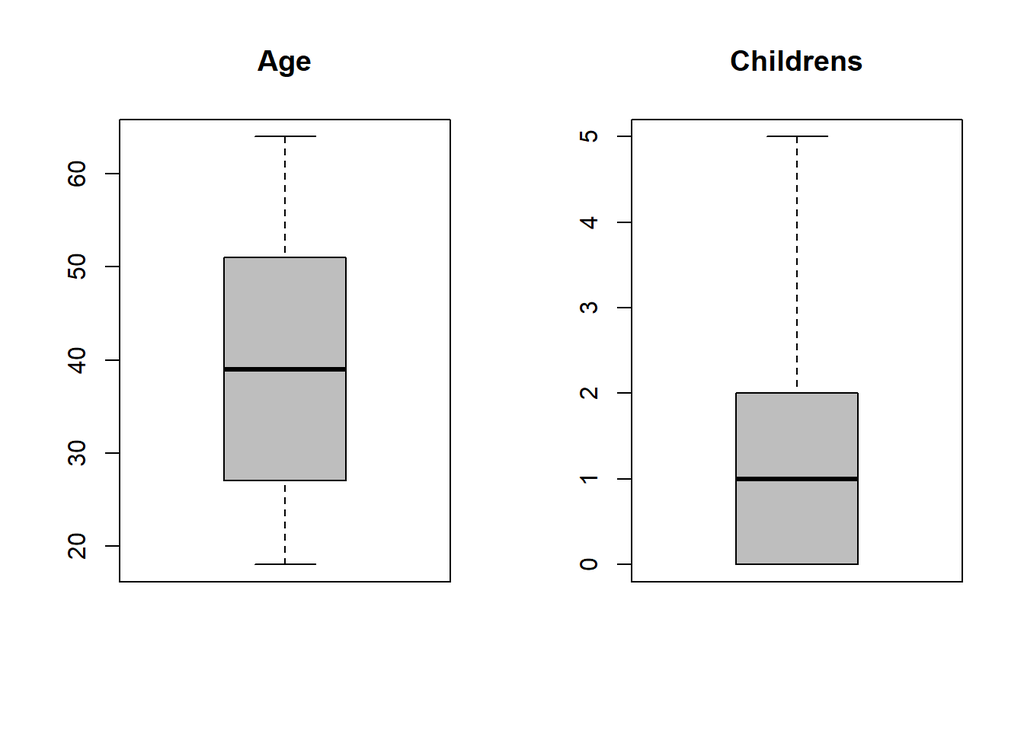

```r
par(mfrow = c(1,2))
boxplot(insurance$age, main='Age', col = 'grey')
boxplot(insurance$children, main='Childrens', col = 'grey')
```

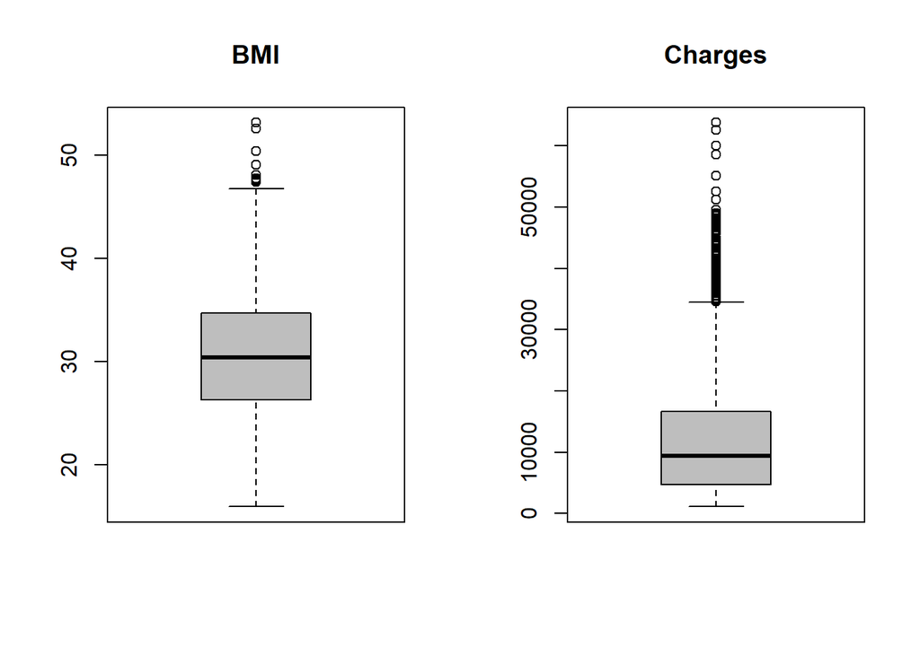

```r
boxplot(insurance$bmi, main='BMI', col = 'grey')
boxplot(insurance$charges, main='Charges', col = 'grey')
```

Parace que hay valores atípicos (outliners) en las variables **bmi** y **charges**. Motivo por el cual se debe inspeccionar mása en detalle:

```r
boxplot.stats(insurance$bmi)$out
```

```
## [1] 49.06 48.07 47.52 47.41 50.38 47.60 52.58 47.74 53.13
```

```r
length(boxplot.stats(insurance$bmi)$out)
```

```
## [1] 9
```

```r
boxplot.stats(insurance$charges)$out
```

```
##   [1] 39611.76 36837.47 37701.88 38711.00 35585.58 51194.56 39774.28 48173.36
##   [9] 38709.18 37742.58 47496.49 37165.16 39836.52 43578.94 47291.06 47055.53
##  [17] 39556.49 40720.55 36950.26 36149.48 48824.45 43753.34 37133.90 34779.61
##  [25] 38511.63 35160.13 47305.31 44260.75 41097.16 43921.18 36219.41 46151.12
##  [33] 42856.84 48549.18 47896.79 42112.24 38746.36 42124.52 34838.87 35491.64
##  [41] 42760.50 47928.03 48517.56 41919.10 36085.22 38126.25 42303.69 46889.26
##  [49] 46599.11 39125.33 37079.37 35147.53 48885.14 36197.70 38245.59 48675.52
##  [57] 63770.43 45863.21 39983.43 45702.02 58571.07 43943.88 39241.44 42969.85
##  [65] 40182.25 34617.84 42983.46 42560.43 40003.33 45710.21 46200.99 46130.53
##  [73] 40103.89 34806.47 40273.65 44400.41 40932.43 40419.02 36189.10 44585.46
##  [81] 43254.42 36307.80 38792.69 55135.40 43813.87 39597.41 36021.01 45008.96
##  [89] 37270.15 42111.66 40974.16 46113.51 46255.11 44202.65 48673.56 35069.37
##  [97] 39047.29 47462.89 38998.55 41999.52 41034.22 36580.28 35595.59 42211.14
## [105] 44423.80 37484.45 39725.52 44501.40 39727.61 48970.25 39871.70 34672.15
## [113] 41676.08 44641.20 41949.24 36124.57 38282.75 46661.44 40904.20 36898.73
## [121] 52590.83 40941.29 39722.75 37465.34 36910.61 38415.47 41661.60 60021.40
## [129] 47269.85 49577.66 37607.53 47403.88 38344.57 34828.65 62592.87 46718.16
## [137] 37829.72 36397.58 43896.38
```

```r
length(boxplot.stats(insurance$charges)$out)
```

```
## [1] 139
```

En total hay 9 valores extremos en la variable **bmi** y 139 valores extremos de la variable **charges**. Si embargo, al consultar en diferentes fuentes externas los valores que se presentan son coherentes, por ejemplo, con los índices de masa corporal de personas con obesidad, y primas de seguro muy elevadas de personas con factores de riesgo alto. Quizá un estudio más avanzado podría realizarse si se tiene los valores de BMI de acuerdo a las edades y conocer los valores máximos que normalmente se encuentran, de manera que se pueda verificar a fondo si son valores extremos.

# 4 Análisis de los datos.

Antes de seleccionar los grupos de datos, sería conveniente analizar un poco los datos que se tienen. Por ello, es importante analizar de manera visual algunas de las características, en especial analizar la distribución de la variable de salida.

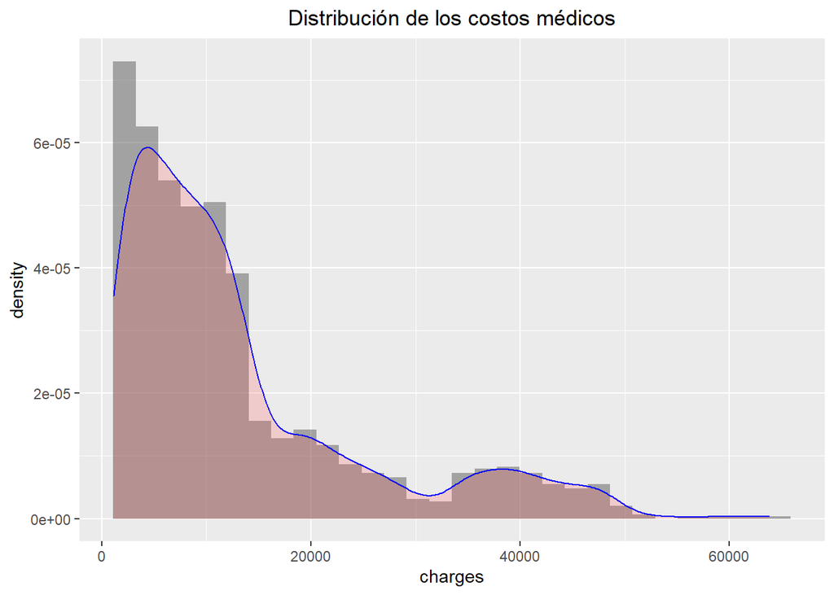

```r
ggplot(insurance, aes(charges)) +
    geom_histogram(aes(y=..density..), alpha = 0.5)  +
    geom_density(fill = "#ff4d4d", alpha = 0.2, col="blue") +
    labs(title = "Distribución de los costos médicos") +
    theme(plot.title = element_text(hjust = 0.5))
```

## 4.1 Selección de los grupos de datos que se quieren analizar/comparar (planificación de los análisis a aplicar).

Vista la importancia del género y el hábito de fumar se realizará una agrupación por condición

```r
insurance.fumadores <- insurance[insurance$smoker=='yes',]
insurance.nofumadores <- insurance[insurance$smoker=='no',]
insurance.mujer <- insurance[insurance$sex=='female',]
insurance.hombre <- insurance[insurance$sex=='male',]
```

## 4.2 Comprobación de la normalidad y homogeneidad de la varianza.

Para comprobar la normalidad de la varianza, se pueden realizar los gráficos **cuantil-cuantil** para ver como son las distribuciones y luego realizar un **test de Shapiro Wilk** en las variables cuantitativas como **age**, **children**, **bmi**, y **charges**.

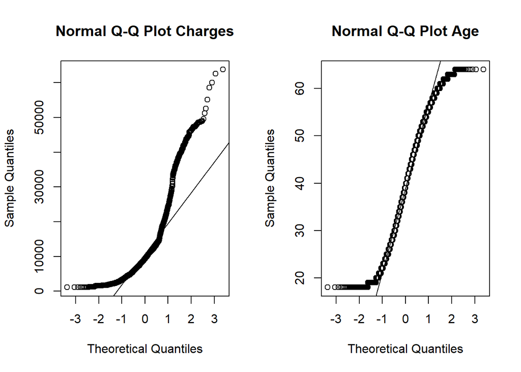

```r
par(mfrow = c(1,2))
qqnorm(insurance$charges, main='Normal Q-Q Plot Charges')
qqline(insurance$charges)

qqnorm(insurance$age, main='Normal Q-Q Plot Age')
qqline(insurance$age)
```

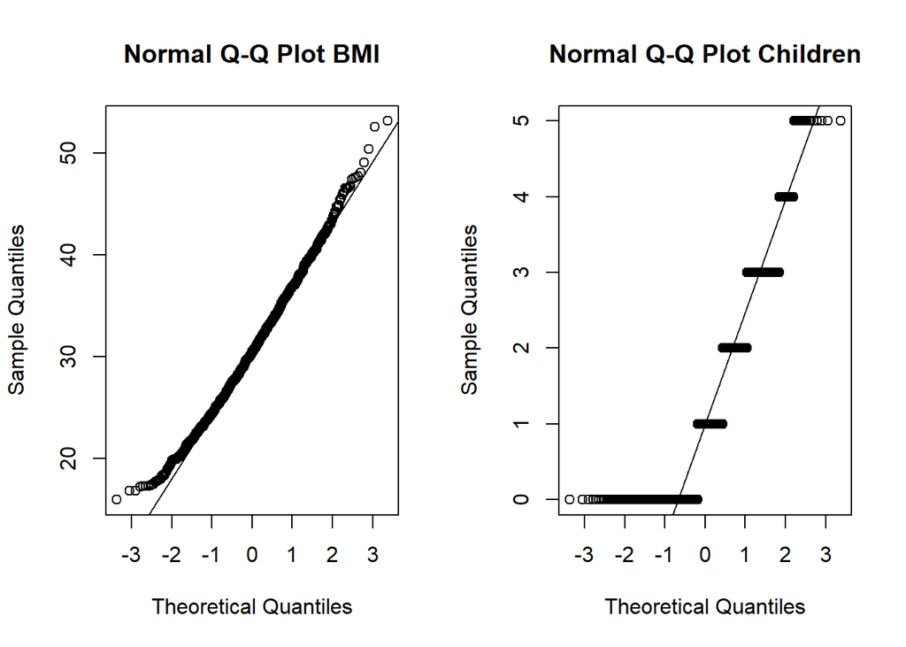

```r
qqnorm(insurance$bmi, main='Normal Q-Q Plot BMI')
qqline(insurance$bmi)

qqnorm(insurance$children, main='Normal Q-Q Plot Children')
qqline(insurance$children)
```

```r
insurance.cuantit <- insurance[, c(1,3,4,7)]

alpha = 0.05

for(i in 1:length(insurance.cuantit)){
  if(shapiro.test(insurance.cuantit[,i])$p.value<alpha){
    cat('Se rechaza la hipótesis nula ya que la variable', names(insurance.cuantit)[i],
        'no sigue una distribución normal.\n')
  }
  else{
    cat('No se rechaza la hipótesis nula ya que la variable', names(insurance.cuantit)[i],
        'sigue una distribución normal.\n')
  }
}
```

```
## Se rechaza la hipótesis nula ya que la variable age no sigue una distribución normal.
## Se rechaza la hipótesis nula ya que la variable bmi no sigue una distribución normal.
## Se rechaza la hipótesis nula ya que la variable children no sigue una distribución normal.
## Se rechaza la hipótesis nula ya que la variable charges no sigue una distribución normal.
```

Las pruebas de *Shapiro Wilk* permiten comprobar que los datos no siguen una distribución normal, por tanto se utilizarán pruebas no paramétricas para realizar el análisis. Esto no podría haber sido visto de manera superficial, ya que en algunos gráficos pareciera que la distribución no se aleja mucho de la normal,

Para comprobar la homogeneidad de la varianza respecto a la prima del seguro es posible utilizar el test ** Fligner-Killeen**:

```r
fligner.test(charges ~ age, data=insurance)
```

```
##
##  Fligner-Killeen test of homogeneity of variances
##
## data:  charges by age
## Fligner-Killeen:med chi-squared = 78.585, df = 46, p-value = 0.001952
```

```r
fligner.test(charges ~ sex, data=insurance)
```

```
##
##  Fligner-Killeen test of homogeneity of variances
##
## data:  charges by sex
## Fligner-Killeen:med chi-squared = 9.4445, df = 1, p-value = 0.002118
```

```r
fligner.test(charges ~ bmi, data=insurance)
```

```
##
##  Fligner-Killeen test of homogeneity of variances
##
## data:  charges by bmi
## Fligner-Killeen:med chi-squared = 610.72, df = 536, p-value = 0.01375
```

```r
fligner.test(charges ~ children, data=insurance)
```

```
##
##  Fligner-Killeen test of homogeneity of variances
##
## data:  charges by children
## Fligner-Killeen:med chi-squared = 22.198, df = 5, p-value = 0.0004801
```

```r
fligner.test(charges ~ smoker, data=insurance)
```

```
##
##  Fligner-Killeen test of homogeneity of variances
##
## data:  charges by smoker
## Fligner-Killeen:med chi-squared = 238.15, df = 1, p-value < 2.2e-16
```

```r
fligner.test(charges ~ region, data=insurance)
```

```
##
##  Fligner-Killeen test of homogeneity of variances
##
## data:  charges by region
## Fligner-Killeen:med chi-squared = 19.233, df = 3, p-value = 0.0002447
```

En todos los casos se rechaza la hipótesis nula de que las varianzas sean iguales, al tener un p-valor muy inferior a 0.05.

Dado que el tamaño de nuestra muestra es superior a 30 observaciones, se puede asumir una tendencia a la distribución normal, debido al Teorema Central del Límite.

## 4.3 Aplicación de pruebas estadísticas para comparar los grupos de datos. En función de los datos y el objetivo del estudio, aplicar pruebas de contraste de hipótesis, correlaciones, regresiones, etc.}}

En primer lugar, es posible analizar la correlación entre las diferentes variables cuantitativas de manera visual

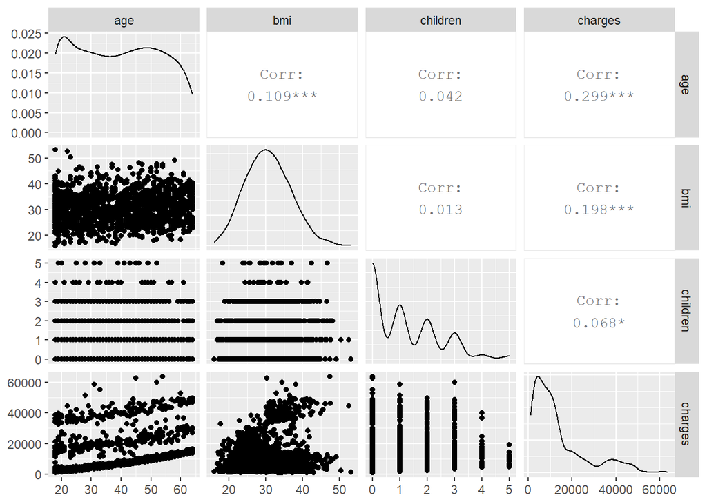

```r
options(dplyr.summarise.inform = FALSE)
ggpairs(insurance, columns = c("age", "bmi", "children", "charges" ), progress = FALSE)
```

Es posible analizar la correlación entre variables cuantitativas a partir del **coeficiente de Spearman**. De esta forma podemos identificar cuáles con las variables más correlacionadas con el importe de la prima del seguro.

```r
cor.test(insurance$charges, insurance$age, method = 'spearman')
```

```
##
##  Spearman's rank correlation rho
##
## data:  insurance$charges and insurance$age
## S = 185881923, p-value < 2.2e-16
## alternative hypothesis: true rho is not equal to 0
## sample estimates:
##       rho
## 0.5343921
```

```r
cor.test(insurance$charges, insurance$bmi, method = 'spearman')
```

```
##
##  Spearman's rank correlation rho
##
## data:  insurance$charges and insurance$bmi
## S = 351556968, p-value = 1.192e-05
## alternative hypothesis: true rho is not equal to 0
## sample estimates:
##       rho
## 0.1193996
```

```r
cor.test(insurance$charges, insurance$children, method = 'spearman')
```

```
##
##  Spearman's rank correlation rho
##
## data:  insurance$charges and insurance$children
## S = 345992058, p-value = 9.847e-07
## alternative hypothesis: true rho is not equal to 0
## sample estimates:
##       rho
## 0.1333389
```

La variable más relevante en función de la prima del seguro es la edad.

Es posible realizar dos contraste de hipótesis para las agrupaciones de hábitos de fumar y género. Dado que los tamaños de los grupos son superiores a 30, gracias al Teorema Central del Límite, se puede realizar el contraste a partir del estadístico *t*.

Primero se contrasta el hecho de que el valor medio de las primas del seguro de los fumadores y no fumadores sea igual, con el de que el valor medio de las primas del seguro de los no fumadores sea inferior al valor medio de las primas del seguro de los fumadores.

$$\left\{
\begin{array}{ll}
H_0 : \mu_{fumNo} = \mu_{fumSi} \rightarrow \mu_{fumNo} - \mu_{fumSi} =0\\
H_1 : \mu_{fumNo} < \mu_{fumSi} \rightarrow \mu_{fumNo} - \mu_{fumSi} <0
\end{array}
\right.$$

```r
t.test(insurance.nofumadores$charges, insurance.fumadores$charges, mu=0,
       conf.level = 0.95, alternative = 'less')
```

```
##
##  Welch Two Sample t-test
##
## data:  insurance.nofumadores$charges and insurance.fumadores$charges
## t = -32.752, df = 311.85, p-value < 2.2e-16
## alternative hypothesis: true difference in means is less than 0
## 95 percent confidence interval:
##      -Inf -22426.4
## sample estimates:
## mean of x mean of y
##  8434.268 32050.232
```

Gracias a esto se rechaza la hipótesis nula de que las primas del seguro médico para los fumadores y los no fumadores sean iguales, con un nivel de confianza del 95%, a favor de la hipótesis alternativa de que la prima del seguro es inferior para los no fumadores.

De manera similar se contrasta el hecho de que el valor medio de las primas del seguro para los hombres y para las mujeres sea igual, con el hecho de que el valor medio de las primas del seguro para los hombres sea inferior al valor medio de las primas del seguro para las mujeres.

$$\left\{
\begin{array}{ll}
H_0 : \mu_{H} = \mu_{M} \rightarrow \mu_{H} - \mu_{M} =0\\
H_1 : \mu_{H} < \mu_{M} \rightarrow \mu_{H} - \mu_{M} <0
\end{array}
\right.$$

```r
t.test(insurance.hombre$charges, insurance.mujer$charges, mu=0,
       conf.level = 0.95, alternative ='less')
```

```
##
##  Welch Two Sample t-test
##
## data:  insurance.hombre$charges and insurance.mujer$charges
## t = 2.1009, df = 1313.4, p-value = 0.9821
## alternative hypothesis: true difference in means is less than 0
## 95 percent confidence interval:
##      -Inf 2474.002
## sample estimates:
## mean of x mean of y
##  13956.75  12569.58
```

En este caso, el p-valor es superior al nivel de significación fijado, por lo tanto, no se puede rechazar la hipótesis nula de que las primas del seguro médico para hombres y mujeres sean iguales, con un nivel de confianza del 95%.

Finalmente, se busca predecir la prima del seguro en función de las variables, es posible estimar mediante mínimos cuadrados ordinarios un modelo lineal que explique el valor la prima de los seguros médicos a partir de diferentes regresores.

```r
insurance$sexR <- relevel(insurance$sex, ref = 'female')
insurance$smokerR <- relevel(insurance$smoker, ref = 'yes')
insurance$regionR <- relevel(insurance$region, ref = 'southwest')

regModel.1 <- lm(charges~age+factor(sexR)+bmi+children+factor(smokerR)+factor(regionR),
                 data = insurance)
summary(regModel.1)
```

```
##
## Call:
## lm(formula = charges ~ age + factor(sexR) + bmi + children +
##     factor(smokerR) + factor(regionR), data = insurance)
##
## Residuals:
##      Min       1Q   Median       3Q      Max
## -11305.2  -2848.3   -982.2   1392.6  29992.7
##
## Coefficients:
##                           Estimate Std. Error t value Pr(>|t|)
## (Intercept)               10950.49    1069.97  10.234  < 2e-16 ***
## age                         256.86      11.90  21.587  < 2e-16 ***
## factor(sexR)male           -131.30     332.95  -0.394 0.693390
## bmi                         339.18      28.60  11.859  < 2e-16 ***
## children                    475.51     137.81   3.451 0.000577 ***
## factor(smokerR)no        -23848.60     413.16 -57.723  < 2e-16 ***
## factor(regionR)northeast    960.00     477.94   2.009 0.044778 *
## factor(regionR)northwest    606.99     477.21   1.272 0.203610
## factor(regionR)southeast    -74.92     470.64  -0.159 0.873538
## ---
## Signif. codes:  0 '***' 0.001 '**' 0.01 '*' 0.05 '.' 0.1 ' ' 1
##
## Residual standard error: 6062 on 1329 degrees of freedom
## Multiple R-squared:  0.7509, Adjusted R-squared:  0.7494
## F-statistic: 500.8 on 8 and 1329 DF,  p-value: < 2.2e-16
```

```r
regModel.2 <- lm(charges~age+bmi+children+factor(smokerR),
                 data = insurance)
summary(regModel.2)
```

```
##
## Call:
## lm(formula = charges ~ age + bmi + children + factor(smokerR),
##     data = insurance)
##
## Residuals:
##      Min       1Q   Median       3Q      Max
## -11898.1  -2920.6   -986.6   1392.5  29509.6
##
## Coefficients:
##                    Estimate Std. Error t value Pr(>|t|)
## (Intercept)        11709.11     991.37  11.811  < 2e-16 ***
## age                  257.85      11.90  21.674  < 2e-16 ***
## bmi                  321.84      27.38  11.755  < 2e-16 ***
## children             473.51     137.79   3.436 0.000608 ***
## factor(smokerR)no -23811.47     411.22 -57.904  < 2e-16 ***
## ---
## Signif. codes:  0 '***' 0.001 '**' 0.01 '*' 0.05 '.' 0.1 ' ' 1
##
## Residual standard error: 6068 on 1333 degrees of freedom
## Multiple R-squared:  0.7497, Adjusted R-squared:  0.7489
## F-statistic: 998.1 on 4 and 1333 DF,  p-value: < 2.2e-16
```

```r
regModel.3 <- lm(charges~age+children+factor(smokerR)+factor(regionR),
                 data = insurance)
summary(regModel.3)
```

```
##
## Call:
## lm(formula = charges ~ age + children + factor(smokerR) + factor(regionR),
##     data = insurance)
##
## Residuals:
##      Min       1Q   Median       3Q      Max
## -15656.5  -1939.2  -1302.9   -360.2  28887.2
##
## Coefficients:
##                           Estimate Std. Error t value Pr(>|t|)
## (Intercept)               20533.42     710.25  28.910  < 2e-16 ***
## age                         273.29      12.42  22.012  < 2e-16 ***
## children                    496.86     144.77   3.432 0.000617 ***
## factor(smokerR)no        -23780.51     432.89 -54.934  < 2e-16 ***
## factor(regionR)northeast    484.17     500.44   0.967 0.333478
## factor(regionR)northwest    138.22     499.72   0.277 0.782142
## factor(regionR)southeast    873.98     487.35   1.793 0.073144 .
## ---
## Signif. codes:  0 '***' 0.001 '**' 0.01 '*' 0.05 '.' 0.1 ' ' 1
##
## Residual standard error: 6370 on 1331 degrees of freedom
## Multiple R-squared:  0.7245, Adjusted R-squared:  0.7233
## F-statistic: 583.5 on 6 and 1331 DF,  p-value: < 2.2e-16
```

```r
regModel.4 <- lm(charges~bmi+children+factor(smokerR)+factor(regionR),
                 data = insurance)
summary(regModel.4)
```

```
##
## Call:
## lm(formula = charges ~ bmi + children + factor(smokerR) + factor(regionR),
##     data = insurance)
##
## Residuals:
##    Min     1Q Median     3Q    Max
## -15149  -4634   -839   3583  31989
##
## Coefficients:
##                           Estimate Std. Error t value Pr(>|t|)
## (Intercept)               18532.99    1157.98  16.005  < 2e-16 ***
## bmi                         410.08      32.96  12.441  < 2e-16 ***
## children                    595.39     159.92   3.723 0.000205 ***
## factor(smokerR)no        -23629.82     478.43 -49.391  < 2e-16 ***
## factor(regionR)northeast   1030.31     555.14   1.856 0.063682 .
## factor(regionR)northwest    639.70     554.31   1.154 0.248687
## factor(regionR)southeast   -378.71     546.44  -0.693 0.488406
## ---
## Signif. codes:  0 '***' 0.001 '**' 0.01 '*' 0.05 '.' 0.1 ' ' 1
##
## Residual standard error: 7042 on 1331 degrees of freedom
## Multiple R-squared:  0.6634, Adjusted R-squared:  0.6619
## F-statistic: 437.2 on 6 and 1331 DF,  p-value: < 2.2e-16
```

```r
cat("R2 modelo 1:", summary(regModel.1)$r.squared, "\nR2 modelo 2:",
    summary(regModel.2)$r.squared, "\nR2 modelo 3:", summary(regModel.3)$r.squared,
    "\nR2 modelo 4:", summary(regModel.4)$r.squared)
```

```
## R2 modelo 1: 0.7509089
## R2 modelo 2: 0.7496906
## R2 modelo 3: 0.7245445
## R2 modelo 4: 0.6634081
```

Para determinar el mejor modelo, se analizan los coeficientes R cuadrado. Dicho esto, el mejor modelo sería el **RegModel.1** al tener el coeficiente de determinación más elevado. Por lo cual se visualizan las características del modelo seleccionado:

```r
summary(regModel.1)
```

```
##
## Call:
## lm(formula = charges ~ age + factor(sexR) + bmi + children +
##     factor(smokerR) + factor(regionR), data = insurance)
##
## Residuals:
##      Min       1Q   Median       3Q      Max
## -11305.2  -2848.3   -982.2   1392.6  29992.7
##
## Coefficients:
##                           Estimate Std. Error t value Pr(>|t|)
## (Intercept)               10950.49    1069.97  10.234  < 2e-16 ***
## age                         256.86      11.90  21.587  < 2e-16 ***
## factor(sexR)male           -131.30     332.95  -0.394 0.693390
## bmi                         339.18      28.60  11.859  < 2e-16 ***
## children                    475.51     137.81   3.451 0.000577 ***
## factor(smokerR)no        -23848.60     413.16 -57.723  < 2e-16 ***
## factor(regionR)northeast    960.00     477.94   2.009 0.044778 *
## factor(regionR)northwest    606.99     477.21   1.272 0.203610
## factor(regionR)southeast    -74.92     470.64  -0.159 0.873538
## ---
## Signif. codes:  0 '***' 0.001 '**' 0.01 '*' 0.05 '.' 0.1 ' ' 1
##
## Residual standard error: 6062 on 1329 degrees of freedom
## Multiple R-squared:  0.7509, Adjusted R-squared:  0.7494
## F-statistic: 500.8 on 8 and 1329 DF,  p-value: < 2.2e-16
```

En estos resultados los coeficientes asociados a las variables independientes representan el incremento/reducción del coste del seguro cuando dicha variable aumenta/disminuye y las demás se mantienen constantes.

# 5 Representación de los resultados a partir de tablas y gráficas.

A partir de los datos relevantes, es posible observar de manera gráfica algunas de las conclusiones del modelo:

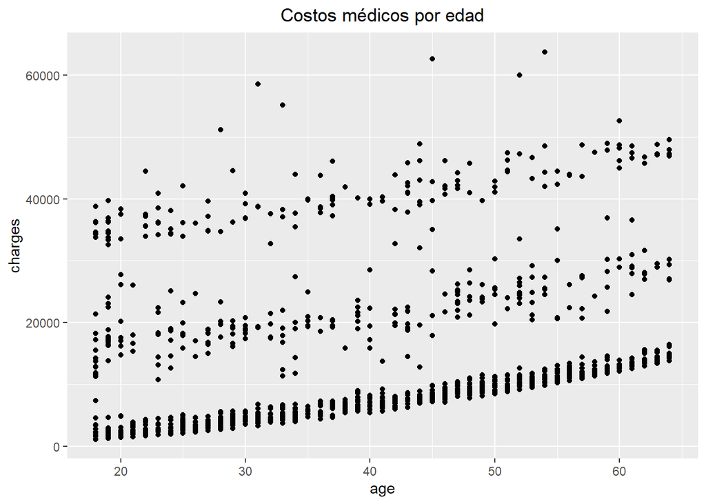

```r
ggplot(insurance, aes(x = age, y = charges)) +
  geom_point() +
  labs(title = "Costos médicos por edad") +
    theme(plot.title = element_text(hjust = 0.5),
          legend.position = "none")
```

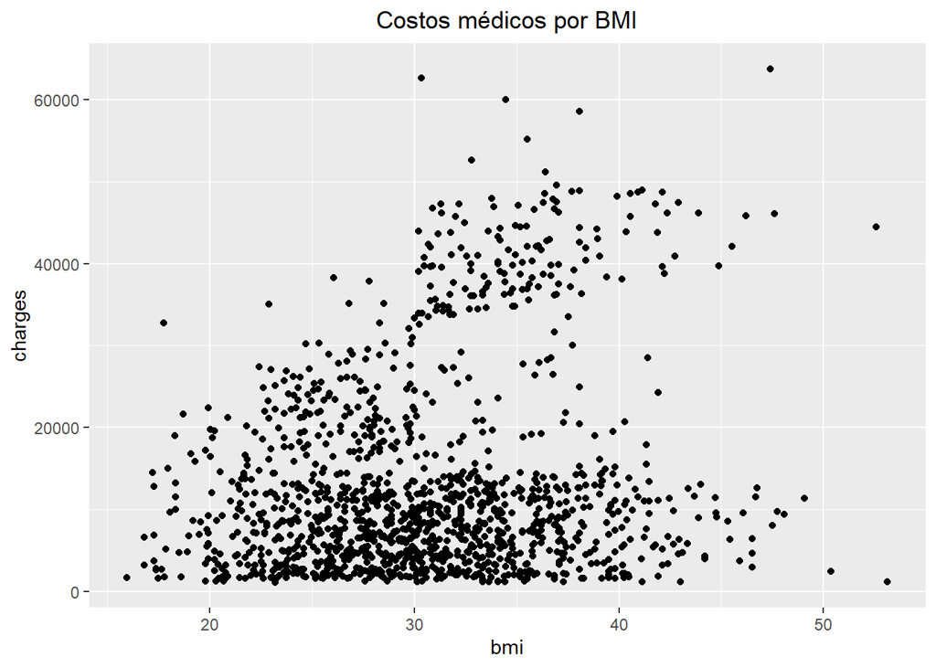

```r
ggplot(insurance, aes(x = bmi, y = charges)) +
  geom_point() +
  labs(title = "Costos médicos por BMI") +
    theme(plot.title = element_text(hjust = 0.5),
          legend.position = "none")
```

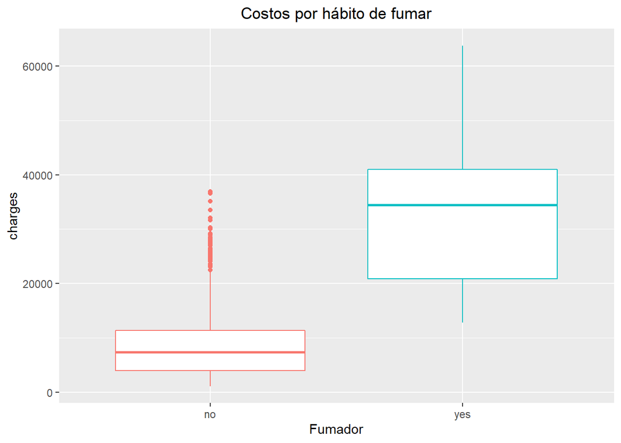

```r
ggplot(insurance, aes(x = as.factor(smoker), y = charges, color = as.factor(smoker))) +
  geom_boxplot() +
  labs(title = "Costos por hábito de fumar",
      x = "Fumador") +
    theme(plot.title = element_text(hjust = 0.5),
          legend.position = "none")
```

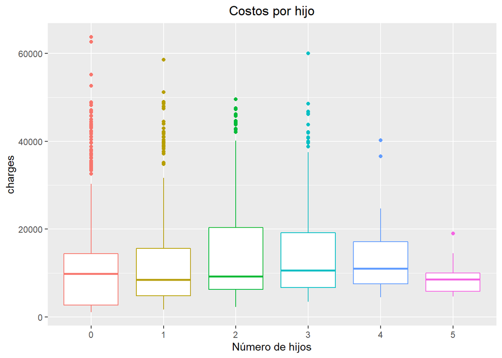

```r
ggplot(insurance, aes(x = as.factor(children), y = charges, color = as.factor(children))) +
  geom_boxplot() +
  labs(title = "Costos por hijo",
      x = "Número de hijos") +
    theme(plot.title = element_text(hjust = 0.5),
          legend.position = "none")
```

También es posible realizar algunas combinaciones de variables para contrastar mejor

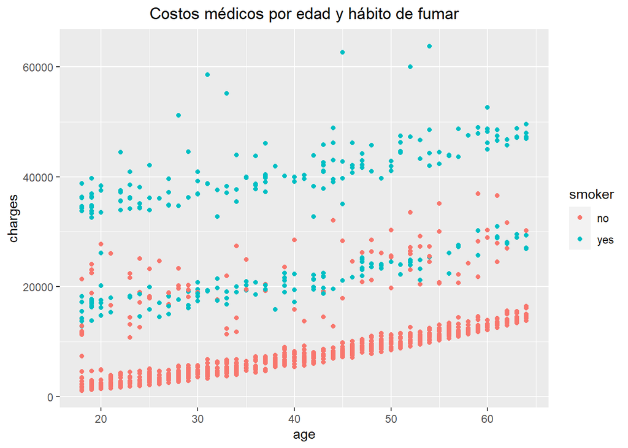

```r
ggplot(insurance, aes(x = age, y = charges, color = smoker)) +
  geom_point()+
  labs(title = "Costos médicos por edad y hábito de fumar") +
    theme(plot.title = element_text(hjust = 0.5))
```

Si se separan por grupos es posible observa una mejor correlación

[figure not shown]

```r
ggplot(insurance, aes(x = age, y = charges, color = smoker)) +
  geom_point() +
  facet_wrap(~smoker) +
  labs(title = "Costos médicos por edad y hábito de fumar") +
    theme(plot.title = element_text(hjust = 0.5))
```

Finalmente es posible hacer este mismo análisis en función de los costos médicos en función de BMI y el hábito de fumar

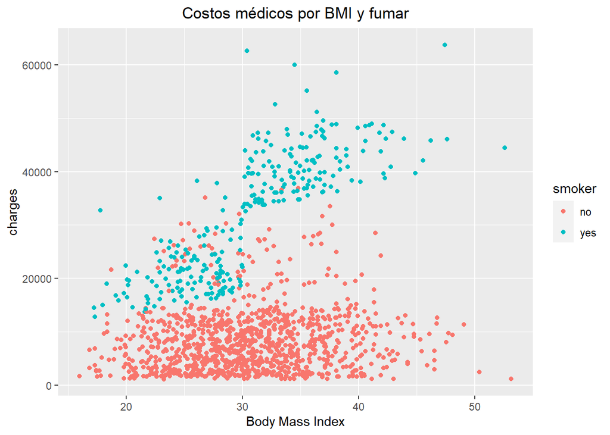

```r
par(mfrow = c(1,2))

ggplot(insurance, aes(x = bmi, y = charges, color = smoker)) +
  geom_point() +
  labs(title = "Costos médicos por BMI y fumar",
      x = "Body Mass Index") +
    theme(plot.title = element_text(hjust = 0.5))
```

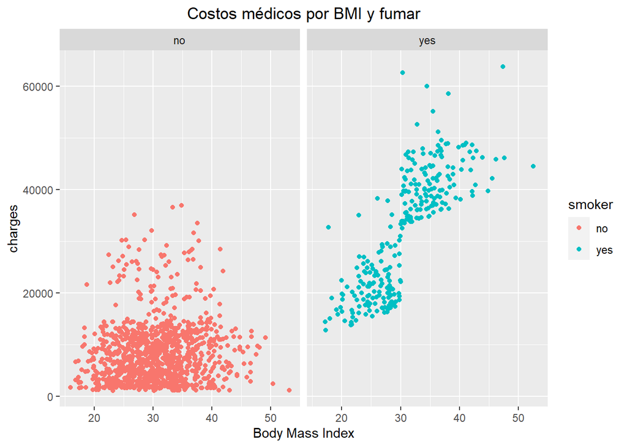

```r
ggplot(insurance, aes(x = bmi, y = charges, color = smoker)) +
  geom_point() +
  labs(title = "Costos médicos por BMI y fumar",
      x = "Body Mass Index") +
    theme(plot.title = element_text(hjust = 0.5)) +
    facet_wrap(~smoker)
```

Tras visualizar todas las graficas de los factores más influyentes se evidencia que el factor de mayor influencia es el hábito de fumador, y que las primas de los seguros se ajustan mucho a cada individuo particular en función de sus características.

Finalmente se exportan los datos ya ajustados

```r
write.csv(insurance, file = 'insurance_clean.csv', row.names = FALSE)
```

# 6 Resolución del problema. A partir de los resultados obtenidos, ¿cuáles son las conclusiones? ¿Los resultados permiten responder al problema?

Después de la limpieza, análisis, y representación de los datos se ha podido concluir:

- Las variables que más influyen en las primas de los seguros médicos son la edad, el índice de masa corporal, el número de hijos, y la condición de fumador o no fumador.
- Se intuye que un asegurado con un índice de masa corporal elevado y fumador tendrá que pagar un seguro más elevado, y más si se tiene en cuenta su edad.
- El modelo de regresión lineal permite predecir el coste de la prima de sus seguros de salud.

# 7 Código: Hay que adjuntar el código, preferiblemente en R, con el que se ha realizado la limpieza, análisis y representación de los datos. Si lo preferís, también podéis trabajar en Python.

El código se encuentra en el archivo ‘PRA2.Rmd’, que está disponible en [este enlace de github](https://github.com/cahucadi/Practica2-M2.851)